# 05_A_TSDecomposition

# References

1. Hyndman, R.J., & Athanasopoulos, G., 2021. *Forecasting: principles and practice*. 3rd edition.
2. Kourentzes, Nikolaus. *Additive and multiplicative seasonality - can you identify them correctly?* [Link](https://kourentzes.com/forecasting/2014/11/09/additive-and-multiplicative-seasonality/#comments)

# Packages

```r
library(fpp3)
```

# Additive vs. multiplicative decomposition

We treat a time series as three components:

- A seasonal component $S_t$
- A trend-cycle component $T_t$
  - Some authors keep trend and cycle apart. **We treat them as one component**, because the usual decomposition algorithms pull them out together and cannot tell them apart.
- The remainder component $R_t$

We distinguish **two decomposition schemes**:

- An **additive scheme**: the size of the seasonal swing around the trend-cycle stays the same as the level of the series rises and falls.

$$\begin{align*}
y_t = S_t + T_t + R_t
\end{align*}$$

- A **multiplicative scheme**: the size of the seasonal swing grows and shrinks in proportion to the level of the series, which is to say in proportion to the trend component.

$$\begin{align*}
y_t = S_t\times{T_t}\times{R_t}
\end{align*}$$

- Here the logarithm is the usual tool. **It turns a purely multiplicative scheme into an additive one:**

$$\begin{align*}
log{y_t}= \log{S_t} + \log{T_t} + \log{R_t}
\end{align*}$$

## Example 1 - Additive scheme

We work with US retail employment, the series in Figure 3.5 of the book: the number of people, in thousands, employed in the US retail sector each month since 1990.

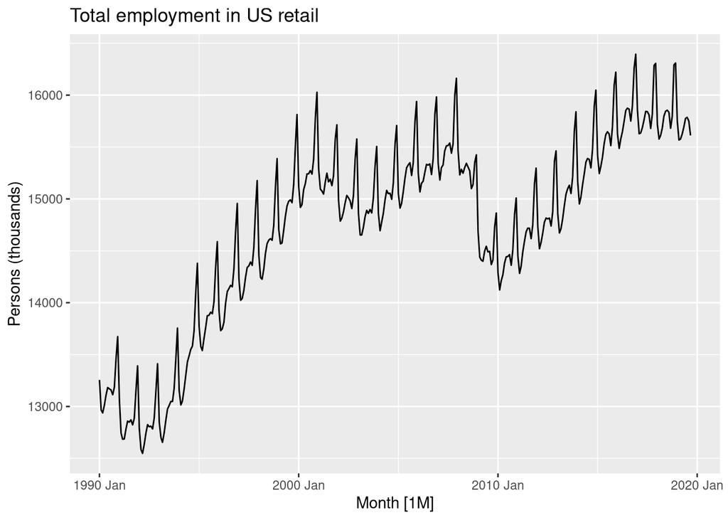

```r
us_retail_employment <- us_employment |>
  filter(year(Month) >= 1990, Title == "Retail Trade") |>
  select(-Series_ID)
autoplot(us_retail_employment, Employed) +
  labs(y = "Persons (thousands)",
       title = "Total employment in US retail")
```

The code below pulls out the components with an STL decomposition. Session 7 covers STL itself. For now, read it as a black box that hands back the three components.

```r
dcmp_components <-

  us_retail_employment |>

  # 1. Define and fit the decomposition model
  # `model()` "fits" the STL model to the `Employed` variable
  model(stl = STL(Employed)) |>

  # 2. Pull the components out of the model. components() only works on
  # models that have components to give: decomposition models, and the ETS
  # models of Session 15 onward.
  components()
```

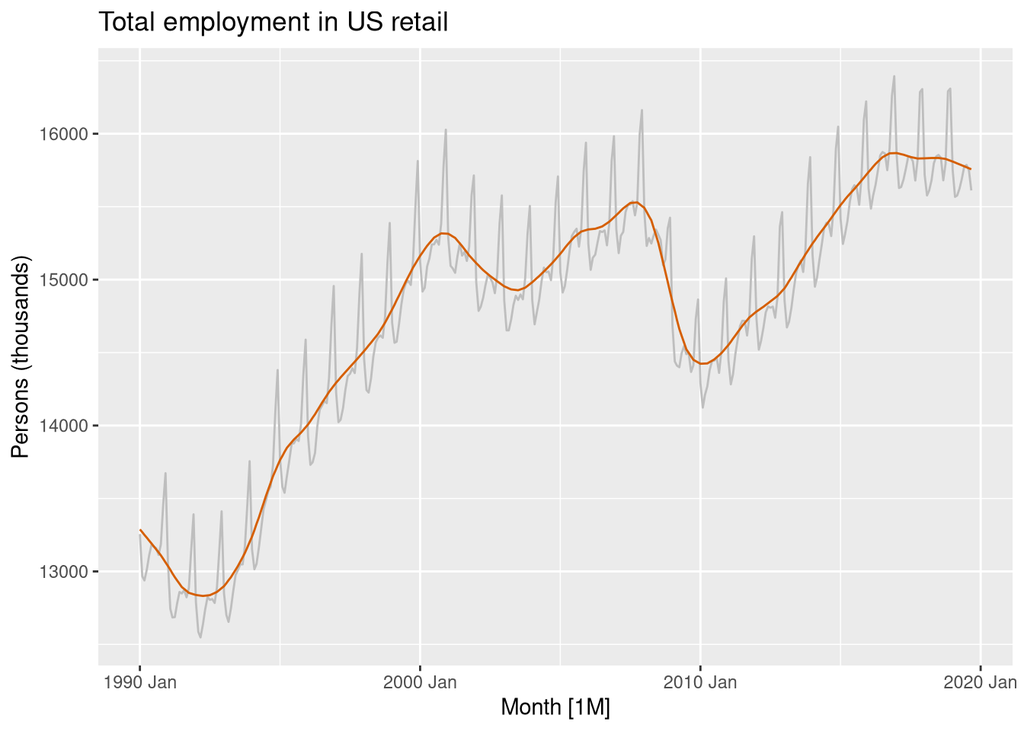

```r
dcmp_components |>

  # 1. Format dataframe to tsibble
  as_tsibble() |>

  # 2. Plot the decomposition using ggplot
  autoplot(Employed, color="gray") +
  geom_line(aes(y=trend), color = "#D55E00") +
  labs(
    y = "Persons (thousands)",
    title = "Total employment in US retail"
  )
```

`autoplot()` shows all three components at once:

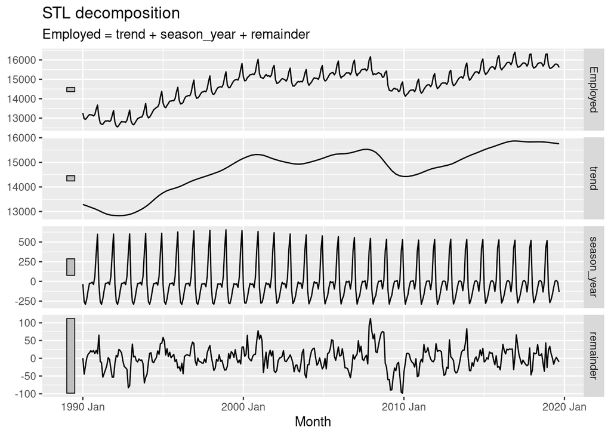

```r
dcmp_components |> autoplot()
```

## Example 2 - Multiplicative scheme

We go back to the monthly Australian prescription data, which shows a clear multiplicative scheme:

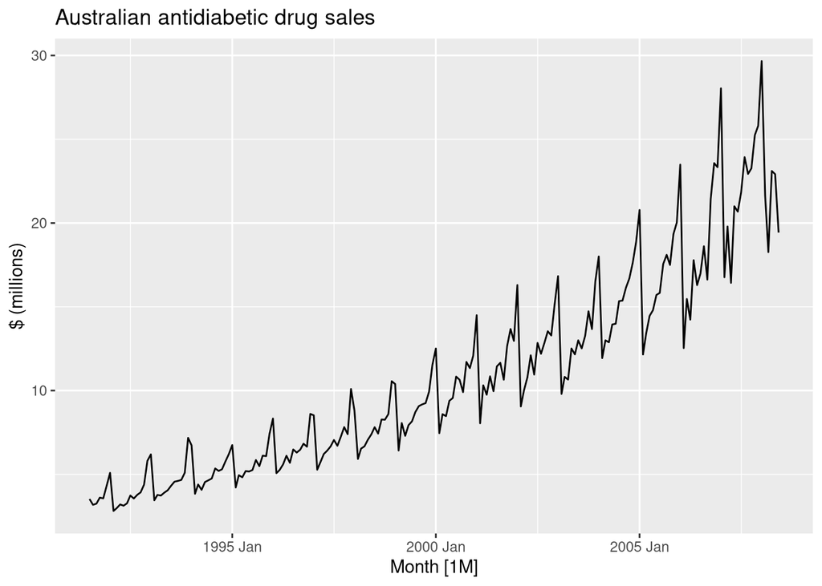

```r
a10 <-
  # 1. Dataframe containing monthly medicare expenses per type of drug
  PBS |>

  # 2. Filter for antidiabetic drugs
  filter(ATC2 == "A10") |>

  # 3. Select subset of columns
  select(Month, Concession, Type, Cost) |>

  # 4. Add the total expenditure per month
  index_by(Month) |>
  summarise(TotalC = sum(Cost)) |>

  # 5. Scale to millions
  mutate(Cost = TotalC / 1e6)

  # 6. Plot
  autoplot(a10, Cost) +
    labs(y = "$ (millions)",
         title = "Australian antidiabetic drug sales")
```

```r
# Examine the dataset
a10
```

```
## # A tsibble: 204 x 3 [1M]
##       Month  TotalC  Cost
##       <mth>   <dbl> <dbl>
##  1 1991 Jul 3526591  3.53
##  2 1991 Aug 3180891  3.18
##  3 1991 Sep 3252221  3.25
##  4 1991 Oct 3611003  3.61
##  5 1991 Nov 3565869  3.57
##  6 1991 Dec 4306371  4.31
##  7 1992 Jan 5088335  5.09
##  8 1992 Feb 2814520  2.81
##  9 1992 Mar 2985811  2.99
## 10 1992 Apr 3204780  3.20
## # ℹ 194 more rows
```

The code below pulls out the components with an X-11 decomposition, a method built for multiplicative series. This course does not teach X-11, so read it here as another black box that hands back the three components.

```r
x11_dcmp <-

  a10 |>

  # 1. Define and fit the decomposition model
  # "~" is syntactic sugar for "apply this method (x11()) to this variable (Cost)"
  model(x11 = X_13ARIMA_SEATS(Cost ~ x11())) |>

  # 2. Pull the components out of the model. components() only works on
  # models that have components to give: decomposition models, and the ETS
  # models of Session 15 onward.
  components()

x11_dcmp
```

```
## # A dable: 204 x 7 [1M]
## # Key:     .model [1]
## # :        Cost = trend * seasonal * irregular
##    .model    Month  Cost trend seasonal irregular season_adjust
##    <chr>     <mth> <dbl> <dbl>    <dbl>     <dbl>         <dbl>
##  1 x11    1991 Jul  3.53  3.44    0.998     1.03           3.54
##  2 x11    1991 Aug  3.18  3.42    0.988     0.941          3.22
##  3 x11    1991 Sep  3.25  3.41    0.964     0.987          3.37
##  4 x11    1991 Oct  3.61  3.41    1.06      0.999          3.41
##  5 x11    1991 Nov  3.57  3.42    1.03      1.01           3.46
##  6 x11    1991 Dec  4.31  3.45    1.29      0.971          3.35
##  7 x11    1992 Jan  5.09  3.48    1.43      1.02           3.55
##  8 x11    1992 Feb  2.81  3.52    0.799     1.000          3.52
##  9 x11    1992 Mar  2.99  3.56    0.852     0.983          3.50
## 10 x11    1992 Apr  3.20  3.60    0.860     1.03           3.73
## # ℹ 194 more rows
```

The code below draws the trend component over the series it came from:

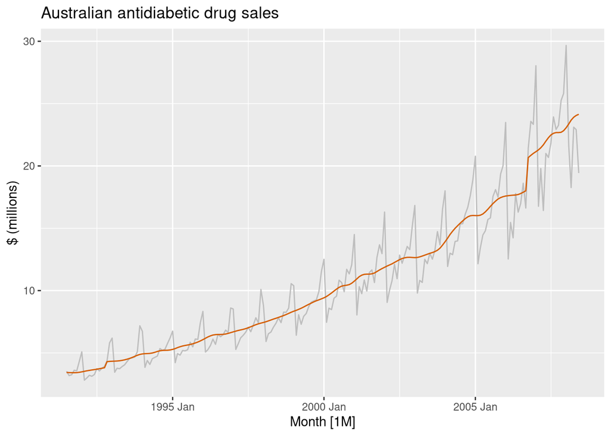

```r
x11_dcmp |>
  as_tsibble() |>
  autoplot(Cost, colour="gray") +
  # Let's now overlay the trend line we modeled
  geom_line(aes(y=trend), colour = "#D55E00") +
  labs(
    y = "$ (millions)",
    title = "Australian antidiabetic drug sales"
  )
```

And again, all the components at once:

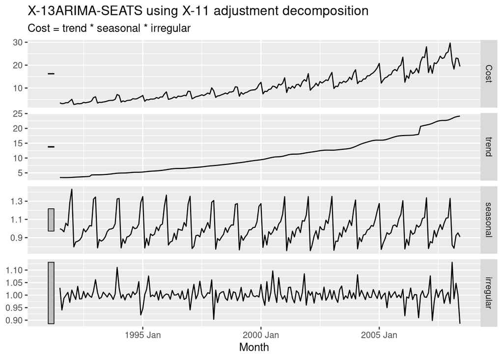

```r
x11_dcmp |> autoplot()
```

## The multiplicative scheme under four transformations

A mathematical transformation can usually make a multiplicative scheme behave more like an additive one. Session 11 covers these transformations properly. Here we take a first look.

We apply four transformations of increasing strength and watch what each one does to the seasonal swing. **The goal is to turn the multiplicative scheme into an additive one.**

The four are a **square root**, a **cubic root**, a **log** and an **inverse** transformation:

```r
a10 <-
  a10 |>

  # Define different versions of the transformed variable
  mutate(
    sqrt_cost = sqrt(Cost),
    cbrt_cost = Cost^(1/3),
    log_cost = log(Cost),
    inv_cost = -1/Cost
    )

a10
```

```
## # A tsibble: 204 x 7 [1M]
##       Month  TotalC  Cost sqrt_cost cbrt_cost log_cost inv_cost
##       <mth>   <dbl> <dbl>     <dbl>     <dbl>    <dbl>    <dbl>
##  1 1991 Jul 3526591  3.53      1.88      1.52     1.26   -0.284
##  2 1991 Aug 3180891  3.18      1.78      1.47     1.16   -0.314
##  3 1991 Sep 3252221  3.25      1.80      1.48     1.18   -0.307
##  4 1991 Oct 3611003  3.61      1.90      1.53     1.28   -0.277
##  5 1991 Nov 3565869  3.57      1.89      1.53     1.27   -0.280
##  6 1991 Dec 4306371  4.31      2.08      1.63     1.46   -0.232
##  7 1992 Jan 5088335  5.09      2.26      1.72     1.63   -0.197
##  8 1992 Feb 2814520  2.81      1.68      1.41     1.03   -0.355
##  9 1992 Mar 2985811  2.99      1.73      1.44     1.09   -0.335
## 10 1992 Apr 3204780  3.20      1.79      1.47     1.16   -0.312
## # ℹ 194 more rows
```

Now look at what each transformation does. The four blocks below repeat themselves on purpose, so you can compare them line by line. In production code, a function or a loop would replace the copy-paste.

### square root transformation

```r
dcmp <- a10 |>
  model(stl = STL(sqrt_cost))
components(dcmp)
```

```
## # A dable: 204 x 7 [1M]
## # Key:     .model [1]
## # :        sqrt_cost = trend + season_year + remainder
##    .model    Month sqrt_cost trend season_year remainder season_adjust
##    <chr>     <mth>     <dbl> <dbl>       <dbl>     <dbl>         <dbl>
##  1 stl    1991 Jul      1.88  1.82     -0.0218    0.0826          1.90
##  2 stl    1991 Aug      1.78  1.83     -0.0215   -0.0207          1.81
##  3 stl    1991 Sep      1.80  1.83     -0.0154   -0.0155          1.82
##  4 stl    1991 Oct      1.90  1.84      0.0332    0.0242          1.87
##  5 stl    1991 Nov      1.89  1.85      0.0617   -0.0251          1.83
##  6 stl    1991 Dec      2.08  1.86      0.334    -0.120           1.74
##  7 stl    1992 Jan      2.26  1.87      0.372     0.0139          1.88
##  8 stl    1992 Feb      1.68  1.88     -0.249     0.0470          1.93
##  9 stl    1992 Mar      1.73  1.89     -0.148    -0.0124          1.88
## 10 stl    1992 Apr      1.79  1.90     -0.152     0.0439          1.94
## # ℹ 194 more rows
```

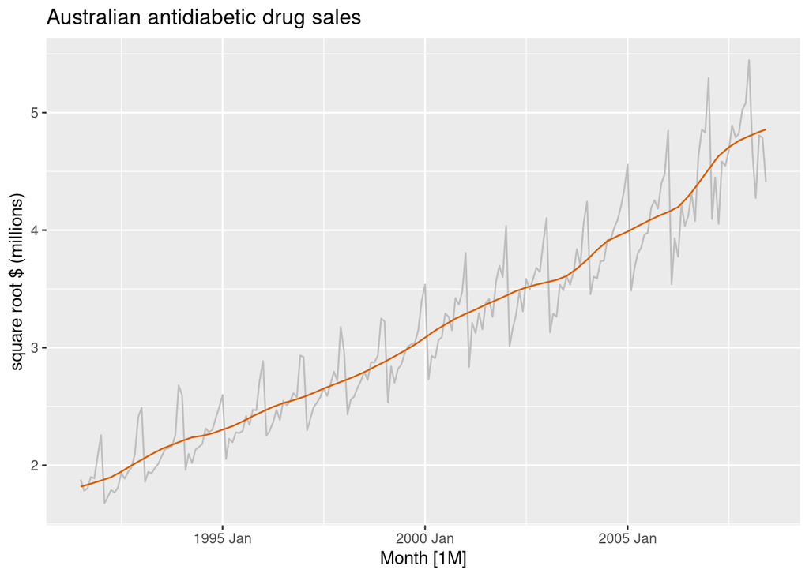

```r
components(dcmp) |>
  as_tsibble() |>
  autoplot(sqrt_cost, colour="gray") +
  geom_line(aes(y=trend), colour = "#D55E00") +
  labs(
    y = "square root $ (millions)",
    title = "Australian antidiabetic drug sales"
  )
```

### cubic root transformation

```r
dcmp <- a10 |>
  model(stl = STL(cbrt_cost))
components(dcmp)
```

```
## # A dable: 204 x 7 [1M]
## # Key:     .model [1]
## # :        cbrt_cost = trend + season_year + remainder
##    .model    Month cbrt_cost trend season_year remainder season_adjust
##    <chr>     <mth>     <dbl> <dbl>       <dbl>     <dbl>         <dbl>
##  1 stl    1991 Jul      1.52  1.49    -0.0100     0.0419          1.53
##  2 stl    1991 Aug      1.47  1.49    -0.0103    -0.0135          1.48
##  3 stl    1991 Sep      1.48  1.50    -0.00720   -0.0101          1.49
##  4 stl    1991 Oct      1.53  1.50     0.0176     0.0134          1.52
##  5 stl    1991 Nov      1.53  1.51     0.0323    -0.0124          1.50
##  6 stl    1991 Dec      1.63  1.51     0.166     -0.0513          1.46
##  7 stl    1992 Jan      1.72  1.52     0.185      0.0179          1.53
##  8 stl    1992 Feb      1.41  1.52    -0.126      0.0161          1.54
##  9 stl    1992 Mar      1.44  1.53    -0.0746    -0.0124          1.51
## 10 stl    1992 Apr      1.47  1.53    -0.0761     0.0186          1.55
## # ℹ 194 more rows
```

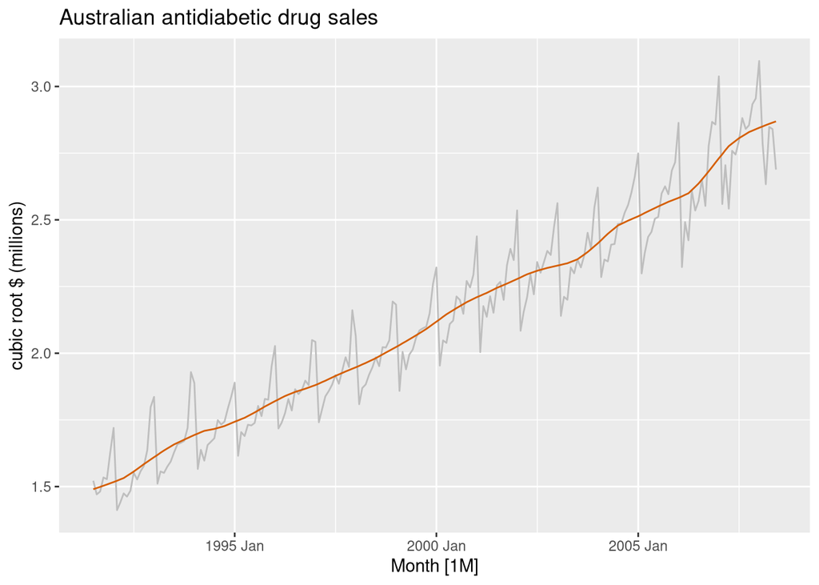

```r
components(dcmp) |>
  as_tsibble() |>
  autoplot(cbrt_cost, colour="gray") +
  geom_line(aes(y=trend), colour = "#D55E00") +
  labs(
    y = "cubic root $ (millions)",
    title = "Australian antidiabetic drug sales"
  )
```

### logarithmic transformation

```r
dcmp <- a10 |>
  model(stl = STL(log_cost))
components(dcmp)
```

```
## # A dable: 204 x 7 [1M]
## # Key:     .model [1]
## # :        log_cost = trend + season_year + remainder
##    .model    Month log_cost trend season_year remainder season_adjust
##    <chr>     <mth>    <dbl> <dbl>       <dbl>     <dbl>         <dbl>
##  1 stl    1991 Jul     1.26  1.20     -0.0136  0.0736            1.27
##  2 stl    1991 Aug     1.16  1.21     -0.0162 -0.0344            1.17
##  3 stl    1991 Sep     1.18  1.22     -0.0105 -0.0255            1.19
##  4 stl    1991 Oct     1.28  1.22      0.0332  0.0279            1.25
##  5 stl    1991 Nov     1.27  1.23      0.0600 -0.0196            1.21
##  6 stl    1991 Dec     1.46  1.24      0.278  -0.0567            1.18
##  7 stl    1992 Jan     1.63  1.25      0.311   0.0684            1.32
##  8 stl    1992 Feb     1.03  1.26     -0.221  -0.000911          1.26
##  9 stl    1992 Mar     1.09  1.27     -0.128  -0.0439            1.22
## 10 stl    1992 Apr     1.16  1.27     -0.130   0.0195            1.29
## # ℹ 194 more rows
```

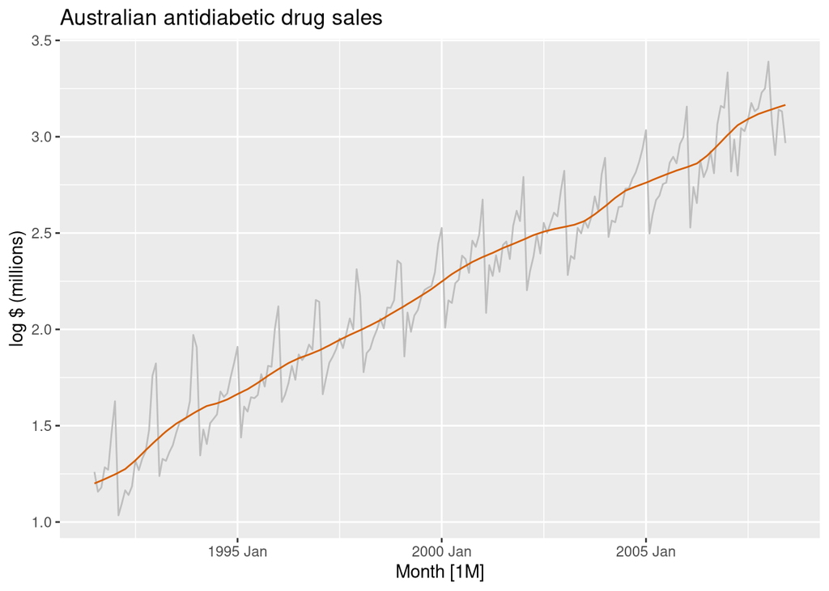

```r
components(dcmp) |>
  as_tsibble() |>
  autoplot(log_cost, colour="gray") +
  geom_line(aes(y=trend), colour = "#D55E00") +
  labs(
    y = "log $ (millions)",
    title = "Australian antidiabetic drug sales"
  )
```

### inverse transformation

```r
dcmp <- a10 |>
  model(stl = STL(inv_cost))
components(dcmp)
```

```
## # A dable: 204 x 7 [1M]
## # Key:     .model [1]
## # :        inv_cost = trend + season_year + remainder
##    .model    Month inv_cost  trend season_year remainder season_adjust
##    <chr>     <mth>    <dbl>  <dbl>       <dbl>     <dbl>         <dbl>
##  1 stl    1991 Jul   -0.284 -0.300  -0.0000614   0.0161         -0.283
##  2 stl    1991 Aug   -0.314 -0.298  -0.00252    -0.0138         -0.312
##  3 stl    1991 Sep   -0.307 -0.297  -0.000907   -0.00998        -0.307
##  4 stl    1991 Oct   -0.277 -0.295   0.00852     0.00965        -0.285
##  5 stl    1991 Nov   -0.280 -0.293   0.0144     -0.00149        -0.295
##  6 stl    1991 Dec   -0.232 -0.292   0.0509      0.00844        -0.283
##  7 stl    1992 Jan   -0.197 -0.290   0.0574      0.0359         -0.254
##  8 stl    1992 Feb   -0.355 -0.288  -0.0464     -0.0213         -0.309
##  9 stl    1992 Mar   -0.335 -0.285  -0.0253     -0.0242         -0.310
## 10 stl    1992 Apr   -0.312 -0.283  -0.0249     -0.00388        -0.287
## # ℹ 194 more rows
```

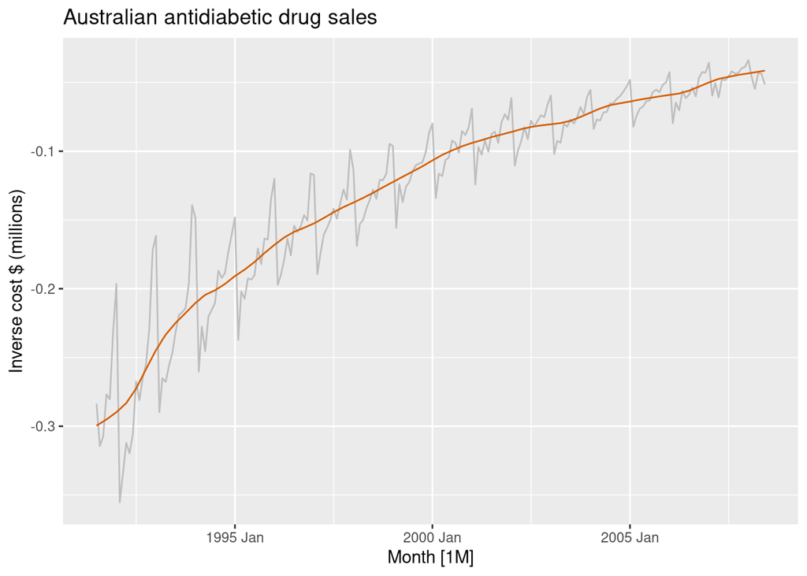

```r
components(dcmp) |>
  as_tsibble() |>
  autoplot(inv_cost, colour="gray") +
  geom_line(aes(y=trend), colour = "#D55E00") +
  labs(
    y = "Inverse cost $ (millions)",
    title = "Australian antidiabetic drug sales"
  )
```

### The transformations, ranked by strength

Ranked by **how hard each one pulls a multiplicative scheme toward an additive one**:

$$\sqrt{x} < \sqrt[3]{x} < log(x) < \frac{1}{x}$$

## More visual examples of the two schemes

Reference
$$2$$
also has a **short interactive game for spotting the visual cues of each scheme**. Spend ten minutes on it. It is the fastest way to build an eye for this.

## Automating the additive-vs-multiplicative decision

Looking at the picture is the right first move, and it builds the intuition an analyst needs. It does not scale. With hundreds of series to process you need a rule a machine can apply. Two are worth knowing.

One rule:

1. Decompose the series twice: once with a method built for additive schemes, once with a method built for multiplicative ones.
2. Measure how well each one fits. For example, check how much autocorrelation is left in the remainder of each decomposition. That is the correlogram from Session 4, now pointed at what a model failed to explain.

Another rule:

1. Fit an exponential smoothing with an additive scheme
2. Fit an exponential smoothing with a multiplicative scheme.
3. Compare their Akaike Information Criterion ($AIC$ or $AIC_c$) and keep the better fit.

Both rules lean on machinery from later sessions. By the end of the course you will be able to run either one.

# Detrended and seasonally adjusted series

## The detrended series

If $T_t$ is the trend-cycle component, the **detrended series** $D_t$ is what is left once you take the trend out.

**How you take it out depends on the scheme:**

| Additive scheme $y_t = T_t + S_t + R_t$ | Multiplicative scheme $y_t = T_t \cdot S_t \cdot R_t$ |
| --- | --- |
| $$D_t = y_t - T_t = S_t + R_t$$ | $$D_t = \frac{y_t}{T_t} = S_t \cdot R_t$$ |

## The seasonally adjusted series

If $S_t$ is the seasonal component, the **seasonally adjusted series** $A_t$ is what is left once you take the seasonal component out.

**Again, how you take it out depends on the scheme:**

| Additive scheme $y_t = T_t + S_t + R_t$ | Multiplicative scheme $y_t = T_t \cdot S_t \cdot R_t$ |
| --- | --- |
| $$A_t = y_t - S_t = T_t + R_t$$ | $$A_t = \frac{y_t}{S_t} = T_t \cdot R_t$$ |

The seasonally adjusted series still carries **the remainder on top of the trend-cycle, so it is not smooth. Its short-term wobbles come from the remainder, and they can fool you into reading a change of direction that is not there.**

- The slope jumps from one step to the next, because the remainder jumps. The trend-cycle component moves smoothly, so it is the better series for reading overall direction.
- To **look for turning points**, use the trend-cycle component, not the seasonally adjusted series.

Seasonally adjusted data is useful when the seasonal variation is not what you are asking about.

- Example: **unemployment figures are published seasonally adjusted**, so that a rise reads as a change in the economy rather than the arrival of the summer holidays.

## Example 1: additive scheme

Earlier we looked at `us_retail_employment` and concluded its scheme is additive:

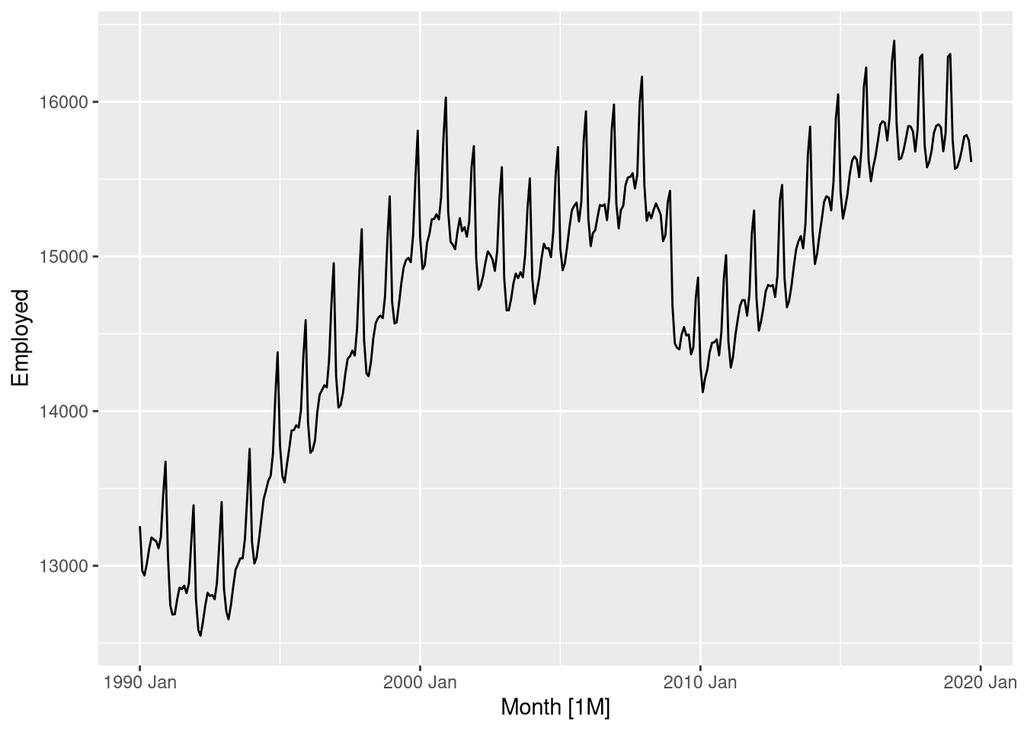

```r
us_retail_employment |> autoplot(Employed)
```

Here we fit a `classical_decomposition` model. Session 7 explains the method and the syntax.

```r
classical_dcmp <-
  us_retail_employment |>

  # 1. Fit the model
  model(
    dcmp = classical_decomposition(Employed, type = "additive")
  ) |>

  # 2. Extract the components
  components()

classical_dcmp
```

```
## # A dable: 357 x 7 [1M]
## # Key:     .model [1]
## # :        Employed = trend + seasonal + random
##    .model    Month Employed  trend seasonal random season_adjust
##    <chr>     <mth>    <dbl>  <dbl>    <dbl>  <dbl>         <dbl>
##  1 dcmp   1990 Jan   13256.    NA    -75.5   NA           13331.
##  2 dcmp   1990 Feb   12966.    NA   -273.    NA           13239.
##  3 dcmp   1990 Mar   12938.    NA   -253.    NA           13191.
##  4 dcmp   1990 Apr   13012.    NA   -190.    NA           13203.
##  5 dcmp   1990 May   13108.    NA    -88.9   NA           13197.
##  6 dcmp   1990 Jun   13183.    NA    -10.4   NA           13193.
##  7 dcmp   1990 Jul   13170. 13178.   -13.3    5.65        13183.
##  8 dcmp   1990 Aug   13160. 13161.    -9.99   8.80        13169.
##  9 dcmp   1990 Sep   13113. 13141.   -87.4   59.9         13201.
## 10 dcmp   1990 Oct   13185. 13117.    34.6   33.8         13151.
## # ℹ 347 more rows
```

The result carries four columns you need:

- `trend`: the trend-cycle component. It is empty at both ends of the series, which Session 6 explains.
- `seasonal`: the seasonal component.
- `random`: the remainder. `classical_decomposition()` uses the older name; everywhere else this course says remainder.
- `season_adjust`: R’s own seasonally adjusted series. This is the column your manual version has to match.

Now compute the **detrended series**. The scheme is additive, so subtract the trend estimate from the original series:

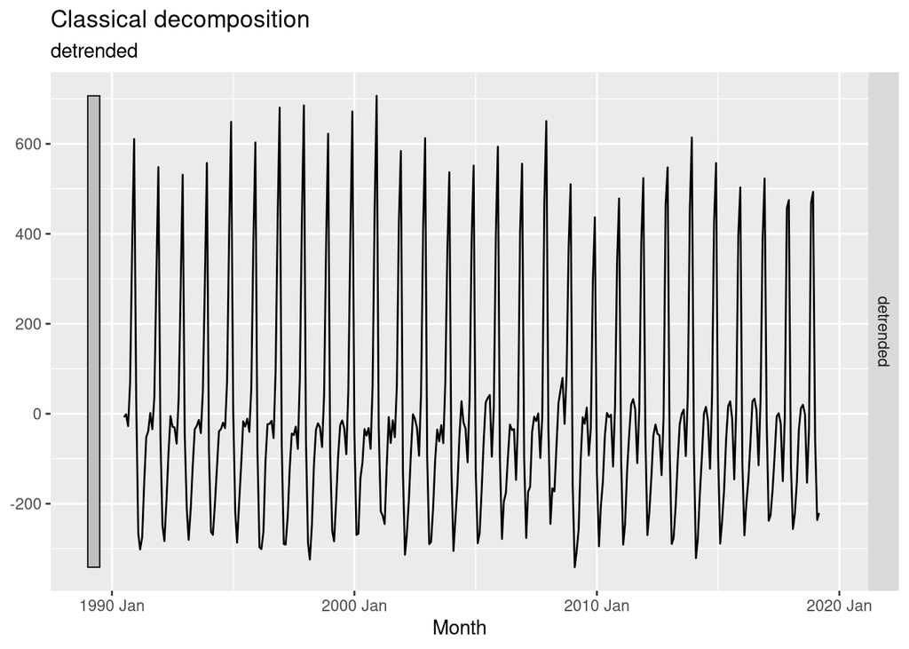

```r
classical_dcmp <-

  classical_dcmp |>

  # Compute new column containing the detrended component
  mutate(
    detrended = Employed - trend
  )

# Plot the result:
classical_dcmp |>
  autoplot(detrended)
```

The detrended series still carries the seasonal component and the remainder.

To get the **seasonally adjusted series**, remove the seasonal component. The scheme is additive, so this is another subtraction. The decomposition already hands us a `season_adjust` column, so we build our own and then check the two agree:

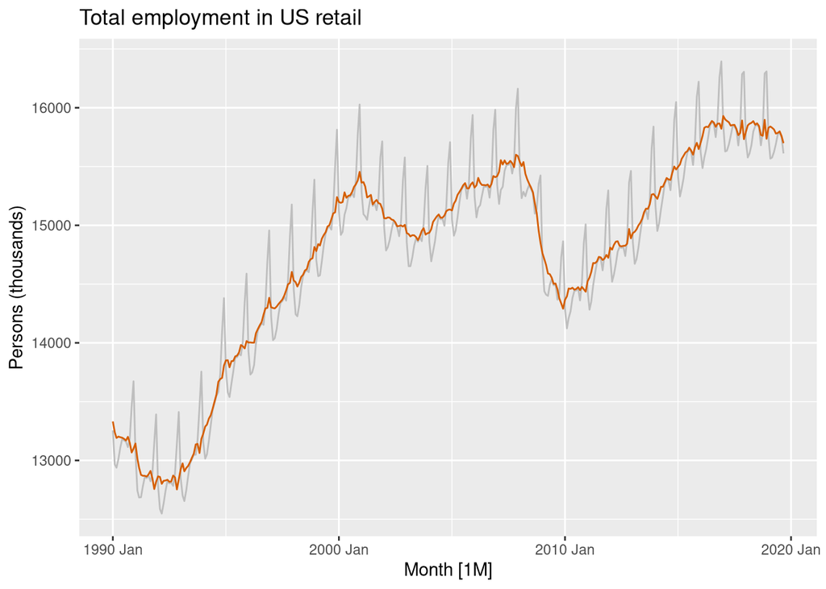

```r
classical_dcmp <-

  classical_dcmp |>

  # Compute new column containing the seasonally adjusted component
  mutate(
    season_adjust_manual = Employed - seasonal
  )

# Plot the result over the original series
classical_dcmp |>
  as_tsibble() |>
  autoplot(Employed, colour="gray") +
  geom_line(aes(y=season_adjust_manual), colour = "#D55E00") +
  labs(
    y = "Persons (thousands)",
    title = "Total employment in US retail"
  )
```

Note that **the seasonally adjusted series is not the trend**. It carries the trend plus the remainder, which you can see in its short-term wobble. Compare it with the trend, plotted just below:

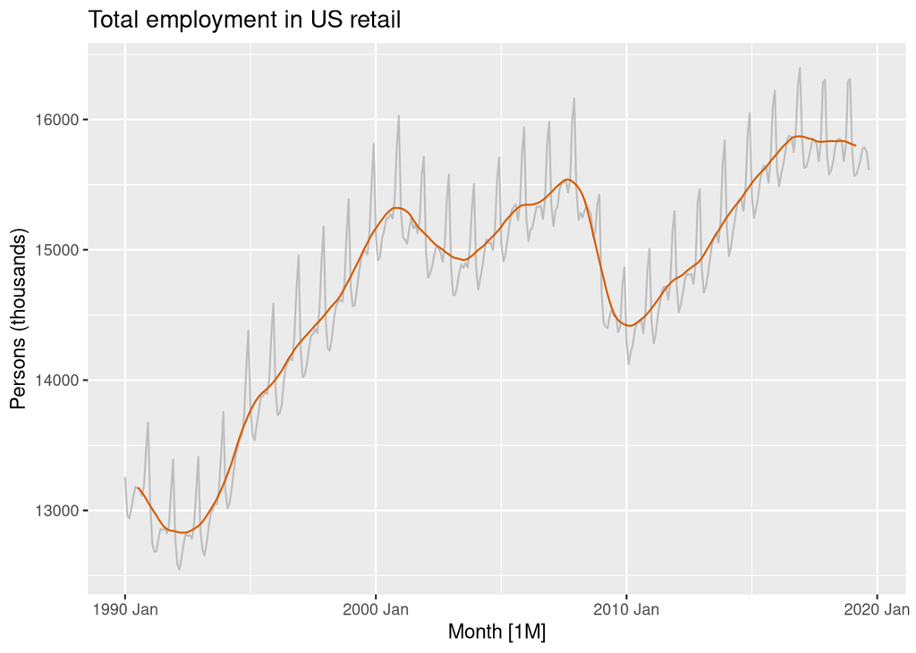

```r
classical_dcmp |>
  as_tsibble() |>
  autoplot(Employed, colour="gray") +
  geom_line(aes(y=trend), colour = "#D55E00") +
  labs(
    y = "Persons (thousands)",
    title = "Total employment in US retail"
  )
```

Side by side, the seasonally adjusted series is visibly rougher. Its dips and rises may be nothing more than remainder. To read turning points, use the trend-cycle component.

### Checking our manual computation with `all.equal()`

Now check that the column we built by hand matches the one `classical_decomposition()` produced.

This is the first time in the course we verify a hand computation against R’s, and it will not be the last. Sessions 6 and 7 build a whole decomposition by hand and check every step this way, so the tool is worth learning properly now.

The obvious tool, `==`, is the wrong one. It compares element by element, and on decimal numbers it reports differences that do not exist:

```r
0.1 + 0.2 == 0.3
```

```
## [1] FALSE
```

That `FALSE` is not an arithmetic mistake. `0.1`, `0.2` and `0.3` cannot be stored exactly in binary, so the sum lands a few quadrillionths away from `0.3`. Two numbers that agree to fifteen decimal places still fail `==`.

`all.equal()` is built for exactly this job. It does **not** compare element by element. It collapses the whole comparison into a single verdict, and it allows a small tolerance, about `1.5e-8` by default:

```r
all.equal(classical_dcmp$season_adjust, classical_dcmp$season_adjust_manual)
```

```
## [1] TRUE
```

Read what comes back carefully, because it has a habit that surprises people:

- When the two objects agree within the tolerance, it returns `TRUE`.
- When they do not, it returns **a character string** describing the gap, such as `"Mean relative difference: 0.1"`. It never returns `FALSE`.

So `all.equal()` answers “are these the same?” with either `TRUE` or an explanation. That makes it unsafe inside an `if`, because a sentence is not a condition:

```r
if (all.equal(1, 1.5)) "same" else "different"
```

```
## Error in `if (all.equal(1, 1.5)) ...`:
## ! argument is not interpretable as logical
```

Wrap it in `isTRUE()` whenever you need a plain `TRUE` or `FALSE`:

```r
isTRUE(all.equal(classical_dcmp$season_adjust, classical_dcmp$season_adjust_manual))
```

```
## [1] TRUE
```

`isTRUE()` turns the character string into `FALSE` and leaves `TRUE` alone. **`isTRUE(all.equal(x, y))` is the idiom to memorize**, and the one to use every time you check a hand computation in this course.

One thing you do *not* need here: rounding the components before you compare them. Absorbing floating-point noise is what the tolerance is for. If you find yourself reaching for `round()` to make a check pass, you have reached for the wrong function.

## Example 2: multiplicative scheme

Earlier we built the dataset `a10`, monthly spending on antidiabetic medication in Australia’s public healthcare system. We concluded its scheme is multiplicative:

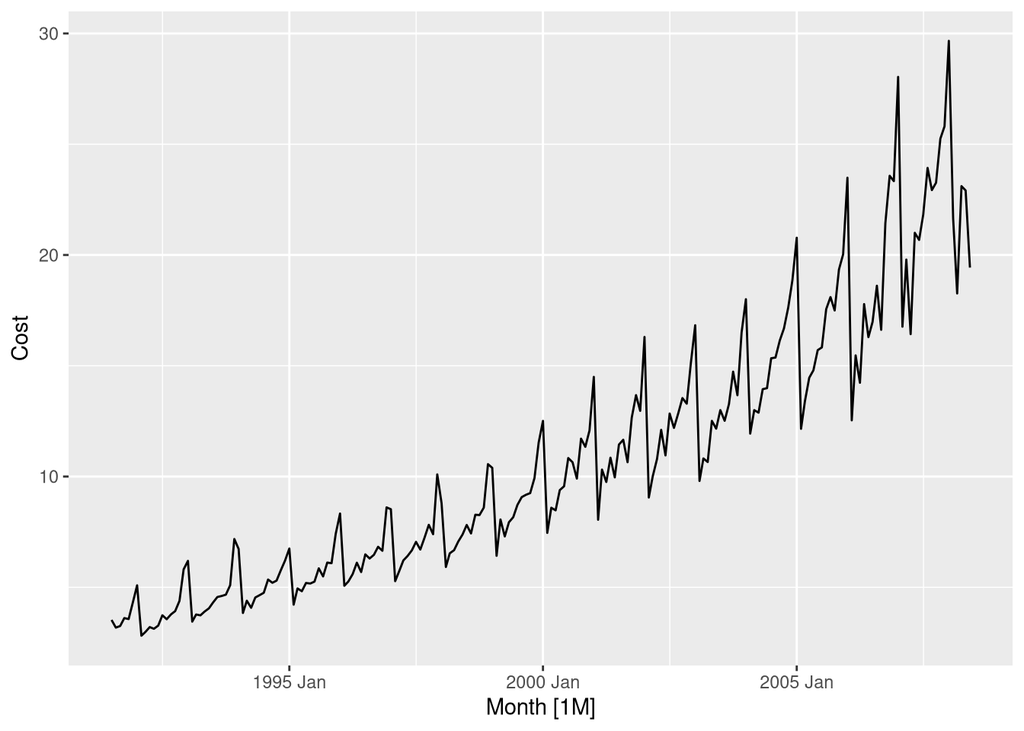

```r
a10 |>
  autoplot(Cost)
```

Here we fit a `classical_decomposition` model. Session 7 explains the method and the syntax.

```r
classical_dcmp <-

  a10 |>

  # 1. Fit the model
  model(
    dcmp = classical_decomposition(Cost, type = "multiplicative")
  ) |>

  # 2. Extract the components
  components()

classical_dcmp
```

```
## # A dable: 204 x 7 [1M]
## # Key:     .model [1]
## # :        Cost = trend * seasonal * random
##    .model    Month  Cost trend seasonal random season_adjust
##    <chr>     <mth> <dbl> <dbl>    <dbl>  <dbl>         <dbl>
##  1 dcmp   1991 Jul  3.53 NA       0.979 NA              3.60
##  2 dcmp   1991 Aug  3.18 NA       0.990 NA              3.21
##  3 dcmp   1991 Sep  3.25 NA       0.986 NA              3.30
##  4 dcmp   1991 Oct  3.61 NA       1.05  NA              3.45
##  5 dcmp   1991 Nov  3.57 NA       1.08  NA              3.32
##  6 dcmp   1991 Dec  4.31 NA       1.23  NA              3.50
##  7 dcmp   1992 Jan  5.09  3.50    1.33   1.09           3.82
##  8 dcmp   1992 Feb  2.81  3.53    0.780  1.02           3.61
##  9 dcmp   1992 Mar  2.99  3.57    0.876  0.956          3.41
## 10 dcmp   1992 Apr  3.20  3.60    0.858  1.04           3.74
## # ℹ 194 more rows
```

The result carries four columns you need:

- `trend`: the trend-cycle component. It is empty at both ends of the series, which Session 6 explains.
- `seasonal`: the seasonal component.
- `random`: the remainder. `classical_decomposition()` uses the older name; everywhere else this course says remainder.
- `season_adjust`: R’s own seasonally adjusted series. This is the column your manual version has to match.

The scheme here is **multiplicative**, so to get the **detrended series** we **divide by the trend estimate** instead of subtracting it:

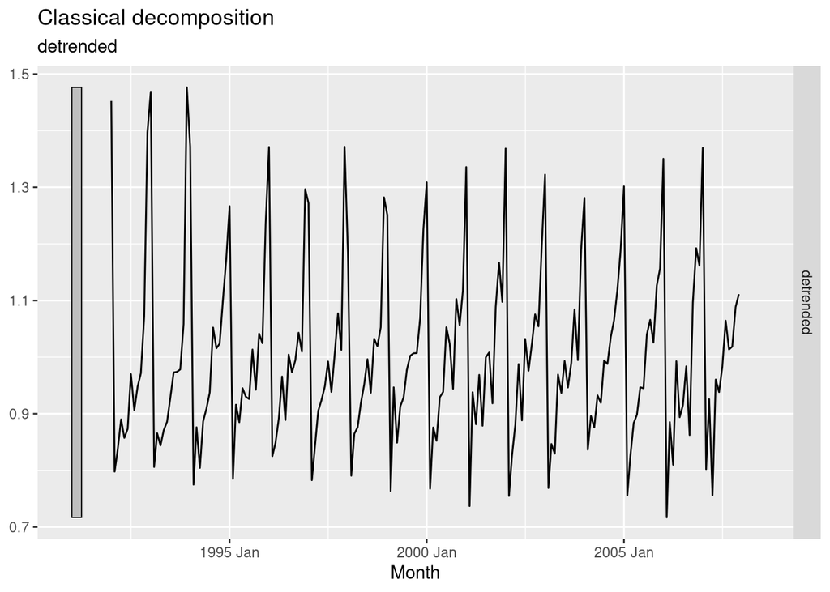

```r
classical_dcmp <-

  classical_dcmp |>

  # Compute new column containing the detrended component
  mutate(
    detrended = Cost / trend
  )

# Plot the result:
classical_dcmp |>
  autoplot(detrended)
```

The detrended series still carries the seasonal component and the remainder.

To get the **seasonally adjusted series**, remove the seasonal component. The scheme is multiplicative, so this is another division. Again the decomposition hands us a `season_adjust` column, so we build our own and check the two agree:

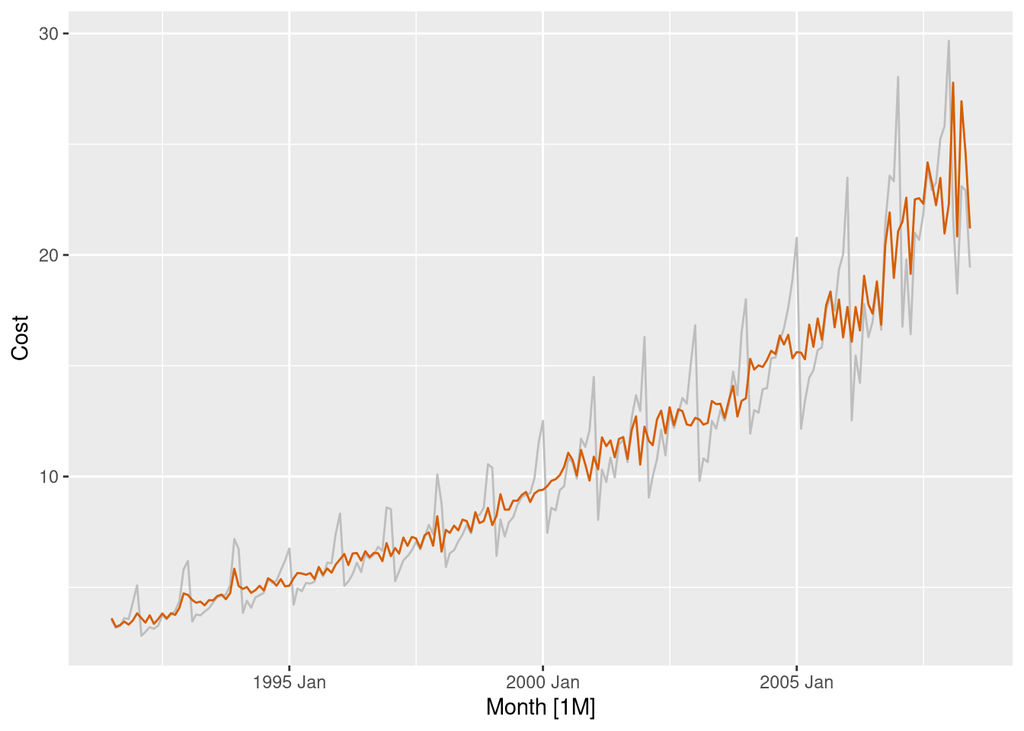

```r
classical_dcmp <-

  classical_dcmp |>

  # Compute new column containing the seasonally adjusted component
  mutate(
    season_adjust_manual = Cost / seasonal
  )

# Plot the result over the original series
classical_dcmp |>
  as_tsibble() |>
  autoplot(Cost, colour="gray") +
  geom_line(aes(y=season_adjust_manual), colour = "#D55E00")
```

Note again that **the seasonally adjusted series is not the trend**. It carries the trend plus the remainder, which you can see in its short-term wobble. Compare it with the trend, plotted just below:

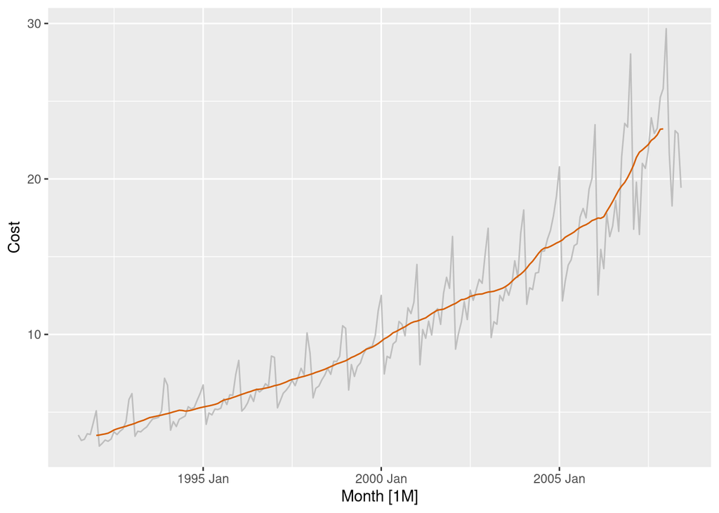

```r
classical_dcmp |>
  as_tsibble() |>
  autoplot(Cost, colour="gray") +
  geom_line(aes(y=trend), colour = "#D55E00")
```

### Checking our manual computation with `all.equal()`

The same check as before, now on the multiplicative series:

```r
all.equal(classical_dcmp$season_adjust, classical_dcmp$season_adjust_manual)
```

```
## [1] TRUE
```

And the version that gives you a result you can act on:

```r
isTRUE(all.equal(classical_dcmp$season_adjust, classical_dcmp$season_adjust_manual))
```

```
## [1] TRUE
```

Remember what a failure looks like. `all.equal()` returns a character string describing the gap, never `FALSE`, so a bare `all.equal()` inside an `if` will throw an error rather than take the other branch. `isTRUE()` is what makes the result safe to use.

# Mixed schemes

Many series do not fall cleanly into either scheme. Session 11 deals with those.

One common in-between case is the *mixed scheme*:

$$\begin{align*}
y_t = (S_t \times T_t ) + R_t
\end{align*}$$

- Trend-cycle and seasonality combine by multiplication.
- The remainder is added on top.

This scheme fits when:

- The remainder $R_t$ does not grow with the level of the series, so it is added rather than multiplied.
- The seasonal component does grow with the level, so it multiplies the trend.